# Spatial modeling of incidence and mortality childhood leukemia based on Colombian armed conflict and poverty for children born during the years 2002-2013

Pilar Montilla, Martha Bohorquez and Rafael Rentería

2021-08-05

**Packages**

```r
rm(list=ls())
require(rgdal)
require(pscl)
require(sf)
require(spdep)
require(spatialreg) #test.W, scores.listw
require(stringr)
require(performance)
require(AER)
require(ggplot2)
require(vcdExtra)
```

**Reading the shapefile of 1124 Colombian municipalities, defining the Coordinate Reference System and centroid and building some variables**

```r
#Reading the shapefile of 1124 Colombian municipalities
muncol <- rgdal::readOGR(dsn="muncol.shp")
muncol=spTransform(muncol,CRS("+init=epsg:21897"))
(l <- length(muncol))
```

```
## [1] 1124
```

```r
#Representative coordinate (centroid)
xy0=data.frame(x=muncol$x,y=muncol$y)
coordinates(xy0) <- c('x','y')
proj4string(xy0) <- CRS("+init=epsg:4326")
xy0=spTransform(xy0,CRS("+init=epsg:21897"))
###Loops for avoiding NA
r <- sum(muncol$NCases)/sum(muncol$NPop)
for (i in 1:l){
   if(muncol$NPop[i]==0){
      muncol$EsperadosNCancer[i] <- 1
   }
   else{
      muncol$EsperadosNCancer[i] <- muncol$NPop[i]*r
   }
}

muncol$IICA_Cat=muncol$IICA_Ca
muncol$IICA_Cat=str_replace_all(muncol$IICA_Cat,"Bajo", "Low")
muncol$IICA_Cat=str_replace_all(muncol$IICA_Cat,"Medio", "Medium")
muncol$IICA_CatLow=ifelse(muncol$IICA_Cat=="Low",1,0)
muncol$IICA_CatMed=ifelse(muncol$IICA_Cat=="Medium",1,0)
muncol$IICA_High=as.character(1-(muncol$IICA_CatLow+muncol$IICA_CatMed))
muncol$UBN=muncol$NBI
```

**Modeling leukemia Incidence Rate (LR) in terms of Colombian armed conflict index, poverty and rurality. First, the usual Poisson regression model with incidence rate as response variable is estimated.**

```r
glmbaseLR<-glm(NCases ~IICA_High+UBN+Per_Rur+offset(log(EsperadosNCancer)), family = poisson,data = muncol)
anova(glmbaseLR)
```

```
## Analysis of Deviance Table
##
## Model: poisson, link: log
##
## Response: NCases
##
## Terms added sequentially (first to last)
##
##
##           Df Deviance Resid. Df Resid. Dev
## NULL                       1123     2524.9
## IICA_High  1     0.75      1122     2524.1
## UBN        1   328.90      1121     2195.2
## Per_Rur    1     0.11      1120     2195.1
```

```r
summary(glmbaseLR)
```

```
##
## Call:
## glm(formula = NCases ~ IICA_High + UBN + Per_Rur + offset(log(EsperadosNCancer)),
##     family = poisson, data = muncol)
##
## Deviance Residuals:
##     Min       1Q   Median       3Q      Max
## -5.1779  -1.1632  -0.5270   0.6082   7.7193
##
## Coefficients:
##               Estimate Std. Error z value Pr(>|z|)
## (Intercept)  0.3226036  0.0276280  11.677  < 2e-16 ***
## IICA_High1   0.0818208  0.0294297   2.780  0.00543 **
## UBN         -0.0123797  0.0010425 -11.875  < 2e-16 ***
## Per_Rur     -0.0002510  0.0007692  -0.326  0.74419
## ---
## Signif. codes:  0 '***' 0.001 '**' 0.01 '*' 0.05 '.' 0.1 ' ' 1
##
## (Dispersion parameter for poisson family taken to be 1)
##
##     Null deviance: 2524.9  on 1123  degrees of freedom
## Residual deviance: 2195.1  on 1120  degrees of freedom
## AIC: 4174.2
##
## Number of Fisher Scoring iterations: 5
```

```r
muncol$residLR=residuals(glmbaseLR)
```

*Rurality is not statistically significant in this first auxiliar model. However, we maintain this variable in the rest of the analysis and review its significance in the final model.*

*Checking excess zeros by comparison between the number of zeros predicted by the model with the observed number of zeros. Also checking overdispersion.*

```r
mu_LR <- predict(glmbaseLR, type = "response")  # predict expected mean count
expLR <- sum(dpois(x = 0, lambda = mu_LR))      # sum the probabilities of a zero count for each mean
round(expLR)                                    #predicted number of zeros
```

```
## [1] 382
```

```r
sum(muncol$NCases < 1)                          #observed number of zeros
```

```
## [1] 443
```

```r
zero.test(muncol$NCases)                        #score test (van den Broek, 1995)
```

```
## Score test for zero inflation
##
##      Chi-square = 12268.7129
##      df = 1
##      pvalue: < 2.22e-16
```

```r
##Checking overdispersion
dispersiontest(glmbaseLR)             #Cameron & Trivedi (1990)
```

```
##
##  Overdispersion test
##
## data:  glmbaseLR
## z = 4.1887, p-value = 1.403e-05
## alternative hypothesis: true dispersion is greater than 1
## sample estimates:
## dispersion
##   2.309041
```

```r
check_overdispersion(glmbaseLR)       #Gelman and Hill (2007)
```

```
## # Overdispersion test
##
##        dispersion ratio =    2.431
##   Pearson's Chi-Squared = 2722.353
##                 p-value =  < 0.001
```

```
## Overdispersion detected.
```

*The observed frequency of zeroes in data exceeds the predicted in the Leukemia incidence rate (LR) model. Also, overdispersion is detected.*

*Now, to validate the independence assumption, first, it is necessary to define spatial weighting possible matrices.*

```r
rook_nb_b=nb2listw(poly2nb(muncol,queen=FALSE), style="B",zero.policy = TRUE)
rook_nb_w=nb2listw(poly2nb(muncol,queen=FALSE), style="W",zero.policy = TRUE)

queen_nb_b=nb2listw(poly2nb(muncol,queen=TRUE), style="B",zero.policy = TRUE)
queen_nb_w=nb2listw(poly2nb(muncol,queen=TRUE), style="W",zero.policy = TRUE)

#Graphs neighbours
trinb=tri2nb(xy0)
options(warn = -1)
tri_nb_b=nb2listw(tri2nb(xy0), style="B",zero.policy = TRUE)
tri_nb_w=nb2listw(tri2nb(xy0), style="W",zero.policy = TRUE)

soi_nb_b=nb2listw(graph2nb(soi.graph(trinb,xy0)), style="B",zero.policy = TRUE)
soi_nb_w=nb2listw(graph2nb(soi.graph(trinb,xy0)), style="W",zero.policy = TRUE)

relative_nb_b=nb2listw(graph2nb(relativeneigh(xy0), sym=TRUE), style="B",zero.policy = TRUE)
relative_nb_w=nb2listw(graph2nb(relativeneigh(xy0), sym=TRUE), style="W",zero.policy = TRUE)

gabriel_nb_b=nb2listw(graph2nb(gabrielneigh(xy0), sym=TRUE), style="B",zero.policy = TRUE)
gabriel_nb_w=nb2listw(graph2nb(gabrielneigh(xy0), sym=TRUE), style="W",zero.policy = TRUE)

#Distance neighbours

knn1_nb_b=nb2listw(knn2nb(knearneigh(xy0, k = 1)), style="B",zero.policy = TRUE)
knn1_nb_w=nb2listw(knn2nb(knearneigh(xy0, k = 1)), style="W",zero.policy = TRUE)
knn2_nb_b=nb2listw(knn2nb(knearneigh(xy0, k = 2)), style="B",zero.policy = TRUE)
knn2_nb_w=nb2listw(knn2nb(knearneigh(xy0, k = 2)), style="W",zero.policy = TRUE)
knn3_nb_b=nb2listw(knn2nb(knearneigh(xy0, k = 3)), style="B",zero.policy = TRUE)
knn3_nb_w=nb2listw(knn2nb(knearneigh(xy0, k = 3)), style="W",zero.policy = TRUE)
knn4_nb_b=nb2listw(knn2nb(knearneigh(xy0, k = 4)), style="B",zero.policy = TRUE)
knn4_nb_w=nb2listw(knn2nb(knearneigh(xy0, k = 4)), style="W",zero.policy = TRUE)
knn6_nb_b=nb2listw(knn2nb(knearneigh(xy0, k = 6)), style="B",zero.policy = TRUE)
knn6_nb_w=nb2listw(knn2nb(knearneigh(xy0, k = 6)), style="W",zero.policy = TRUE)

mat=list(rook_nb_b,rook_nb_w,
         queen_nb_b,queen_nb_w,
         tri_nb_b,tri_nb_w,
         soi_nb_b,soi_nb_w,
         gabriel_nb_b,gabriel_nb_w,
         relative_nb_b,relative_nb_w,
         knn1_nb_b,knn1_nb_w,
         knn2_nb_b,knn2_nb_w,
         knn3_nb_b,knn3_nb_w,
         knn4_nb_b,knn4_nb_w,
         knn6_nb_b,knn6_nb_w)
```

*Testing spatial autocorrelation using Moran index test based on weighting matrices built in the last step. Note that with all weighting matrices we obtain a significant spatial autocorrelation.*

```r
aux=numeric(0)
options(warn = -1)
{
for(i in 1:length(mat))
aux[i]=moran.test(muncol$residLR,mat[[i]],alternative="two.sided")$"p"
}
aux
```

```
##  [1] 1.776445e-09 1.630534e-11 1.116295e-09 3.409196e-11 2.619438e-10
##  [6] 1.984900e-11 2.800074e-11 2.648473e-11 7.073103e-11 4.068005e-12
## [11] 1.345336e-09 5.867655e-09 6.342820e-04 6.342820e-04 5.337856e-09
## [16] 5.337856e-09 4.653660e-12 4.653660e-12 2.138542e-13 2.138542e-13
## [21] 5.932765e-13 5.932765e-13
```

```r
moran.test(muncol$residLR, mat[[which.max(aux)]], alternative="two.sided")
```

```
##
##  Moran I test under randomisation
##
## data:  muncol$residLR
## weights: mat[[which.max(aux)]]
##
## Moran I statistic standard deviate = 3.4165, p-value = 0.0006343
## alternative hypothesis: two.sided
## sample estimates:
## Moran I statistic       Expectation          Variance
##       0.123653792      -0.000890472       0.001328865
```

*First, Poisson Hurdle model is estimated without consider spatial autocorrelation.*

```r
mod.hurdleLR <- hurdle(NCases ~IICA_High+UBN+Per_Rur+offset(log(EsperadosNCancer))|IICA_High+UBN+Per_Rur+offset(log(EsperadosNCancer)),data = muncol,dist = "poisson", zero.dist = "binomial")
resid_Pois_Hurdle=residuals(mod.hurdleLR,"response")
summary(mod.hurdleLR)
```

```
##
## Call:
## hurdle(formula = NCases ~ IICA_High + UBN + Per_Rur + offset(log(EsperadosNCancer)) |
##     IICA_High + UBN + Per_Rur + offset(log(EsperadosNCancer)), data = muncol,
##     dist = "poisson", zero.dist = "binomial")
##
## Pearson residuals:
##     Min      1Q  Median      3Q     Max
## -3.6935 -0.7943 -0.3775  0.6266 17.7799
##
## Count model coefficients (truncated poisson with log link):
##               Estimate Std. Error z value Pr(>|z|)
## (Intercept)  0.3151943  0.0289252  10.897   <2e-16 ***
## IICA_High1   0.0769858  0.0309613   2.487   0.0129 *
## UBN         -0.0123171  0.0011548 -10.666   <2e-16 ***
## Per_Rur      0.0020604  0.0008876   2.321   0.0203 *
## Zero hurdle model coefficients (binomial with logit link):
##              Estimate Std. Error z value Pr(>|z|)
## (Intercept)  1.001514   0.249402   4.016 5.93e-05 ***
## IICA_High1   0.072259   0.137921   0.524    0.600
## UBN         -0.013830   0.003541  -3.906 9.39e-05 ***
## Per_Rur     -0.004660   0.003364  -1.385    0.166
## ---
## Signif. codes:  0 '***' 0.001 '**' 0.01 '*' 0.05 '.' 0.1 ' ' 1
##
## Number of iterations in BFGS optimization: 9
## Log-likelihood: -2051 on 8 Df
```

```r
pR2(mod.hurdleLR)
```

```
## fitting null model for pseudo-r2
```

```
##           llh       llhNull            G2      McFadden          r2ML
## -2051.4697559 -9229.3509481 14355.7623845     0.7777233     0.9999972
##          r2CU
##     0.9999972
```

```r
moran.test(resid_Pois_Hurdle, mat[[which.max(aux)]], alternative="two.sided")
```

```
##
##  Moran I test under randomisation
##
## data:  resid_Pois_Hurdle
## weights: mat[[which.max(aux)]]
##
## Moran I statistic standard deviate = 4.5053, p-value = 6.627e-06
## alternative hypothesis: two.sided
## sample estimates:
## Moran I statistic       Expectation          Variance
##       0.158812671      -0.000890472       0.001256531
```

*Thus, residuals are significantly spatially autocorrelated. So, we are going tu use spatial filtering. Below we find Moran Eigenvectors.*

```r
MEpoisLR <- spatialreg::ME(NCases ~ IICA_High+UBN+Per_Rur+offset(log(EsperadosNCancer)),data=muncol,family="poisson",listw=mat[[3]], alpha=0.02, verbose=TRUE)
```

```
## eV[,29], I: 0.01179903 ZI: NA, pr(ZI): 0.21
```

```r
MoranEigenVLR=data.frame(fitted(MEpoisLR))
```

*Now, we used Poisson Hurdle model to manage the overdispersion due to zero excess and Moran eigenfunctions are included as additional explanatory variables, so that spatial autocorrelation is considered.*

```r
mod.hurdleLR <- hurdle(NCases ~IICA_High+UBN+Per_Rur+fitted(MEpoisLR)+offset(log(EsperadosNCancer))|Per_Rur+offset(log(EsperadosNCancer)),data = muncol,dist = "poisson", zero.dist = "binomial")
resid_Pois_Hurdle=residuals(mod.hurdleLR,"response")
moran.test(resid_Pois_Hurdle, mat[[3]], alternative="two.sided")
```

```
##
##  Moran I test under randomisation
##
## data:  resid_Pois_Hurdle
## weights: mat[[3]]
##
## Moran I statistic standard deviate = 1.0424, p-value = 0.2972
## alternative hypothesis: two.sided
## sample estimates:
## Moran I statistic       Expectation          Variance
##      0.0162024286     -0.0008904720      0.0002689009
```

```r
summary(mod.hurdleLR)
```

```
##
## Call:
## hurdle(formula = NCases ~ IICA_High + UBN + Per_Rur + fitted(MEpoisLR) +
##     offset(log(EsperadosNCancer)) | Per_Rur + offset(log(EsperadosNCancer)),
##     data = muncol, dist = "poisson", zero.dist = "binomial")
##
## Pearson residuals:
##     Min      1Q  Median      3Q     Max
## -3.2263 -0.7927 -0.3875  0.6339 17.8272
##
## Count model coefficients (truncated poisson with log link):
##                    Estimate Std. Error z value Pr(>|z|)
## (Intercept)       0.2275843  0.0328678   6.924 4.38e-12 ***
## IICA_High1        0.1568024  0.0342051   4.584 4.56e-06 ***
## UBN              -0.0113328  0.0011644  -9.733  < 2e-16 ***
## Per_Rur           0.0016899  0.0008965   1.885   0.0594 .
## fitted(MEpoisLR)  2.6540637  0.4767638   5.567 2.59e-08 ***
## Zero hurdle model coefficients (binomial with logit link):
##              Estimate Std. Error z value Pr(>|z|)
## (Intercept)  0.646903   0.213106   3.036   0.0024 **
## Per_Rur     -0.008731   0.003237  -2.697   0.0070 **
## ---
## Signif. codes:  0 '***' 0.001 '**' 0.01 '*' 0.05 '.' 0.1 ' ' 1
##
## Number of iterations in BFGS optimization: 10
## Log-likelihood: -2044 on 7 Df
```

```r
pR2(mod.hurdleLR)
```

```
## fitting null model for pseudo-r2
```

```
##           llh       llhNull            G2      McFadden          r2ML
## -2043.6785123 -9229.3509481 14371.3448717     0.7785675     0.9999972
##          r2CU
##     0.9999973
```

```r
MEpoisLR <- spatialreg::ME(NCases ~ IICA_High+UBN+offset(log(EsperadosNCancer)),data=muncol,family="poisson",listw=mat[[3]], alpha=0.02, verbose=TRUE)
```

```
## eV[,29], I: 0.01112525 ZI: NA, pr(ZI): 0.17
```

```r
MoranEigenVLR=data.frame(fitted(MEpoisLR))
mod.hurdleLR <- hurdle(NCases ~IICA_High+UBN+fitted(MEpoisLR)+offset(log(EsperadosNCancer))|Per_Rur+offset(log(EsperadosNCancer)),data = muncol,dist = "poisson", zero.dist = "binomial")
resid_Pois_Hurdle=residuals(mod.hurdleLR,"response")
moran.test(resid_Pois_Hurdle, mat[[3]], alternative="two.sided")
```

```
##
##  Moran I test under randomisation
##
## data:  resid_Pois_Hurdle
## weights: mat[[3]]
##
## Moran I statistic standard deviate = 1.2484, p-value = 0.2119
## alternative hypothesis: two.sided
## sample estimates:
## Moran I statistic       Expectation          Variance
##      0.0194478991     -0.0008904720      0.0002654261
```

```r
summary(mod.hurdleLR)
```

```
##
## Call:
## hurdle(formula = NCases ~ IICA_High + UBN + fitted(MEpoisLR) + offset(log(EsperadosNCancer)) |
##     Per_Rur + offset(log(EsperadosNCancer)), data = muncol, dist = "poisson",
##     zero.dist = "binomial")
##
## Pearson residuals:
##     Min      1Q  Median      3Q     Max
## -3.3173 -0.7976 -0.3786  0.6607 18.2757
##
## Count model coefficients (truncated poisson with log link):
##                    Estimate Std. Error z value Pr(>|z|)
## (Intercept)       0.2143974  0.0321264   6.674 2.50e-11 ***
## IICA_High1        0.1700350  0.0335266   5.072 3.94e-07 ***
## UBN              -0.0097928  0.0008191 -11.955  < 2e-16 ***
## fitted(MEpoisLR)  2.7262303  0.4759204   5.728 1.01e-08 ***
## Zero hurdle model coefficients (binomial with logit link):
##              Estimate Std. Error z value Pr(>|z|)
## (Intercept)  0.646903   0.213106   3.036   0.0024 **
## Per_Rur     -0.008731   0.003237  -2.697   0.0070 **
## ---
## Signif. codes:  0 '***' 0.001 '**' 0.01 '*' 0.05 '.' 0.1 ' ' 1
##
## Number of iterations in BFGS optimization: 9
## Log-likelihood: -2045 on 6 Df
```

```r
pR2(mod.hurdleLR)
```

```
## fitting null model for pseudo-r2
```

```
##           llh       llhNull            G2      McFadden          r2ML
## -2045.4283395 -9229.3509481 14367.8452173     0.7783779     0.9999972
##          r2CU
##     0.9999973
```

*Hence, Poisson-Hurdle model residuals are not significant spatially autocorrelated. The LR’s positive values depend only on the Index of armed conflict (IICA) and on the unsatisfied basic needs index (UBN) and its zero values depend on the rurality. Note that the model shows good performance, according to pseudo R2 and the comparison between observed and predicted frequencies.*

```r
mf <- model.frame(mod.hurdleLR)
y <- model.response(mf)
w <- model.weights(mf)
if(is.null(w)) w <- rep(1, NROW(y))
max0 <- 20L
obs <- as.vector(xtabs(w ~ factor(y, levels = 0L:max0)))
exp <- colSums(predict(mod.hurdleLR, type = "prob", at = 0L:max0) * w)

fitted_vs_observed <- data.frame(Expected = exp,
                                 Observed = obs)
data <- reshape2::melt(fitted_vs_observed)
```

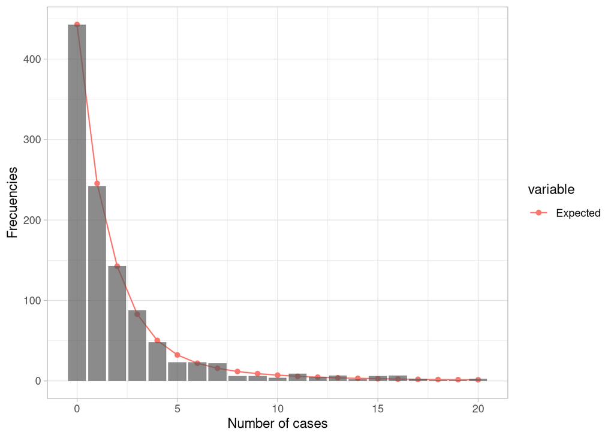

```r
data <- data.frame(data, x =  0:20)
data1 <- data[1:21, ]
data2 <- data[22:42, ]
pl1 <- ggplot() +
  geom_line(data1, mapping = aes(x = x, y = value, group = variable
                          , color = variable)) +
  geom_point(data1, mapping = aes(x = x, y = value, group = variable,
                           color = variable)) +
  geom_col(data2, mapping = aes(x = x, y = value, group = variable),
           alpha = 0.7) +
  theme_light() +
  labs(x = "Number of cases",
       y = "Frecuencies")
pl1
```